# Customer Segmentation Project

Block 1: Customer Analytics Project as part of the Ignitus Scholar Internship

Raymond Lukwago A.R

04-October-2023

## 1.0 Determine the client business needs

This project used the **Single Discrete variable** customer segmentation technique to achieve its objective. More specifically, the project used according to [Aravind, H. (2023)](https://rfm.rsquaredacademy.com/articles/rfm-customer-level-data.html#segmented-customer-data) the **RFM** (recency, frequency, monetary) analysis. This is a behavioural based technique used to segment customers by examining their transaction history as to:

1. how recently a customer has purchased (recency)
2. how often they purchase (frequency)
3. how much the customer spends (monetary)

Essentially, the methodological framework is based off the **pareto principle** that: *80 percent of your business comes from 20 percent of your customers*. The RFM analysis combines the above three customer attributes to rank customers i.e., If they bought in the recent past, they get higher points. If they bought many times, they get higher scores. And if they spent bigger, they get more points. Combined togeter, these three scores create the **Recency - Frequency - Monetary** (RFM) **score**.

Finally, I segmented the customer database into different groups based on this *RFM score*.

### 1.1 Project Objective

This project intended:

> To strategically assist an E-Commence enterprise in identifying and characterising a select group of high-value customers (VIPs), ensuring that this chosen cluster of possesses substantial economic potential for targeted marketing efforts.

### 1.2 Project Questions

Therefore, the project assignment was guided by the following questions:

1. Which group of customers make up the high-value customer (VIPs) segment?
2. What characteristics are common amongst the above select group of high-value customers?

### 1.3 Implementation Process

1. Determine the client business needs
2. Data Sourcing, Cleaning & Exploration
3. Feature Creation
4. Feature Selection
5. Apply RFM Customer Segment Technique
6. Analyse Results & Characterize Segment

### 1.4 About the Data

The Online retail data set was obtained from [UCI Machine Learning Repository](https://archive.ics.uci.edu/dataset/352/online+retail). The data set contains transaction data occurring between **01/12/2010** and **09/12/2011** for a UK-based and registered online retail store. The company mainly sells unique all-occasion gifts. **NB:** Many customers of the company are wholesalers.

## 2.0 Data Sourcing, Cleaning & Exploration

### 2.1 Data Sourcing

#### Import all Necessary Libraries

Installed and loaded all necessary packages for this project. For Data cleaning and exploration, *tidyverse* was used. *GGplot, treemapify and naniar* were used for visualization of, general plots, 3D Matrix plots and missing values respectively. *Knitr and PrettyDoc* was used for R-Markdown templating.

#### Set Working Directory

```r
knitr::opts_knit$set(root.dir = "F:/Projects/Customer_Segmentation_Project")
```

#### Load the Online Retail Data set

```r
df <- read.csv("Ecommerce.csv")
```

#### Initial Data Exploration

An initial exploration of the columns of the data set, type of the data object under each of the columns was done. This is required to understand if the columns and the data under each of the columns meets the overall data set features and variable types.

```r
kable(head(df, 10), longtable = TRUE,
      caption = "Table showing 1st 10 rows of the Original Dataset",
      booktabs = TRUE)
str(df)
colnames(df)
```

[output not shown]

From the initial exploration of the data set, you do realize that there exists one extra column named, **X** that only contains **NA** values. Cross-checking with the original data set requirements above, this is not supposed to be part of the data set and thus was dropped the column from the data set. We also changed the **InvoiceDate** column to data type format, columns; **InvoiceNo, StockCode, Description, CustomerID** & **Country**

We do make a copy of the original imported data set. We shall subsequently make all changes to this duplicate copy. This is a precautionary practice to keep an original that we can revert back to in case something goes wrong with the duplicate copy.

```r
dfCopy <-copy(df)
# Remove the last undesired column
dfCopy <- dplyr::select(dfCopy, -c(9))
# Create a vector object of all columns supposed to be converted to Categorical Data Type
categoricalColumns <- c('InvoiceNo', 'StockCode', 'Description', 'CustomerID', 'Country')
dfCopy[categoricalColumns] <- lapply(dfCopy[categoricalColumns], as.factor)
dfCopy$InvoiceDate <- as.Date(dfCopy$InvoiceDate, "%d-%b-%y")
str(dfCopy)
```

[output not shown]

### 2.2 Data Cleaning

#### Check and Handle Missing Values

The dfCopy data frame has to be further checked for missing values especially NA values in each of the columns. The aim to to remove any NA values under the primary key columns i.e., CustomerID that can be used to track the transaction data of each of customer across the time. Since all columns have zero NA values and only the CUstomerID column has 135,080 missing values. This accounts for 25% of the entire data frame. Since CustomerID column contains a unique Customer ID that identifies a customer (Primary Key), it is illogical to impute the missing values in some way and thus remove all rows with missing values.

```r
# Check for missing values under each of the data frame columns
colSums(is.na(dfCopy))
gg_miss_var(dfCopy)
# Drop all rows under CustomerID column with missing values
dfCopy <- dfCopy %>%
  tidyr::drop_na(CustomerID)
```

[output not shown]

#### Check and Handle Duplicates, Illogical values

```r
SumOfDuplicates <- sum(duplicated(dfCopy))
count_starting_with_C <- sum(startsWith(as.character(dfCopy$InvoiceNo), 'C'))
cleanedDf <- dfCopy %>%
  mutate(InvNo_len = nchar(as.character(InvoiceNo))) %>%
  dplyr::filter(InvNo_len <= 6) %>%
  dplyr::distinct(.keep_all = TRUE)
```

Check for duplicate rows and remove them. It was discovered that there are **5226** duplicate rows and these were removed. We further removed **8905** values under the Invoice ID column that started with letter **‘c’**. This is because from the original data set these values meant a cancellation happened thus a transaction was not completed. During the exploration we discovered that there were illogical values under each of the main columns like the **Unit Price** and **Quantity** columns. Furthermore, it was discovered that all unit prices and quantities under the unit price or quantity columns did not make logical sense for this particular assignment since they were negatives.

Before, this stage of the preliminary analysis, the data frame was composed of **406829**observations. After, the cleaning processes above, we remained with a data frame composed of **392450** observations. We further crosschecked the cleaned data frame for duplicates and illogical values below and zero sums were returned.

```r
count_start_with_C <- sum(startsWith(as.character(cleanedDf$InvoiceNo), 'C'))
SumOfDups_After <- sum(duplicated(cleanedDf))
```

### 2.3 Data Exploration

Conducted quick summary of the descriptive statistics on each of the **cleanedDf** data object to get a better understanding of the structure of our data under each of the columns.

From my summary I learned particularly for column **unit price** that had zero values. Under the **Country** column, I did also notice that there are country names presented as abbreviations. Under the country column, **38** different unique countries were presented and of these three; **USA, RSA** & **EIRE** were country names presented as abbreviations. One column under the same column was labelled **Unspecified**.

Since the percentage of rows that were labelled *Unspecified* accounted for less than 1% of the total data, we took a deliberate decision to remove all rows labelled, *Unspecified*. About the country abbreviations, I undertook some research and established that *EIRE* matches to the Irish Gaelic name for **Ireland**, *RSA* matches to **South Africa** and *USA* matches to **United States of America**. We replaced the mentioned country abbreviations as is below.

Additionally, from the summary statistics we noticed that there were zero values under the **Unit Price** column. We decided to remove these since they could be representing order returns or errors I decided to remove all rows with zero values under the *unit price* column.

```r
summary(cleanedDf)
cleanedDf %>%
  group_by(Country) %>%
  tally() %>%
ungroup()
```

[output not shown]

```r
# Replace all rows in Country column that meets criteria in rep_str
rep_str <- c('EIRE'='Ireland', 'USA'='United States of America', 'RSA'='South Africa')
cleanedDf <- cleanedDf %>%
  mutate(Country = stringr::str_replace_all(Country, rep_str)) %>%
  filter(Country != 'Unspecified', UnitPrice != 0.000) %>%
  mutate(Country = fct_relevel(Country),
         Revenue = Quantity * UnitPrice,
         Recency_days = as.Date("2017-12-08") - InvoiceDate) %>%
  dplyr::select(-c(2,3,9))
```

## 4.0 Feature Selection

In order to create the RFM data set to be used for further analysis, we grouped the data set by unique *customer id* and created three additional columns namely; **Total Revenue, Recency Days** and **Total Orders**. The *Total Revenue* column was calculated from the sum of all revenues by a given customer, *Recency days* column is calculated from the most recent date of transaction purchase date (minimum value under Time_Dist column) and lastly the *Total Orders* column is calculated from the total number of transaction orders done by a particular customer i.e., Row count under each of the customer group.

```r
df_rfm <- cleanedDf %>%
  group_by(CustomerID) %>%
  summarise(
    transaction_count = n(),
    amount = sum(Revenue),
    Recency_days = min(Recency_days)
  ) %>%
  ungroup()
```

### 4.1 Further Data Exploration

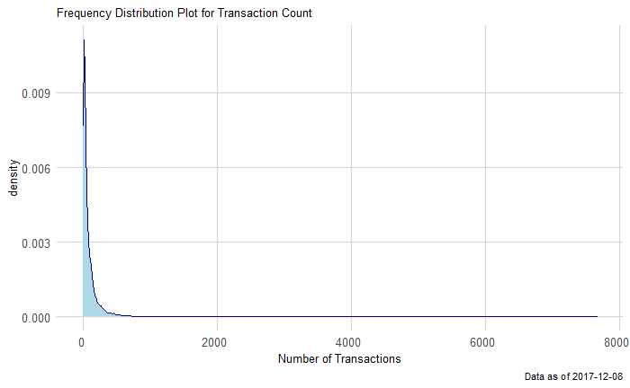

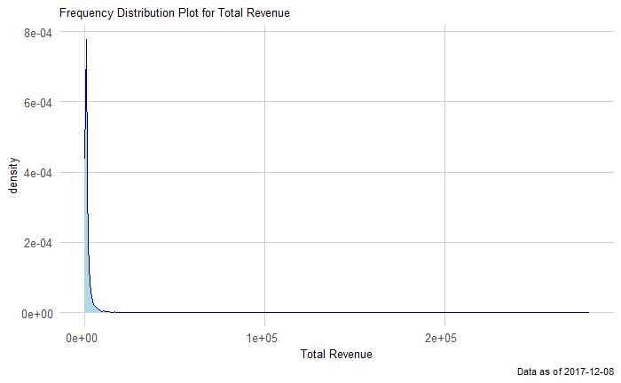

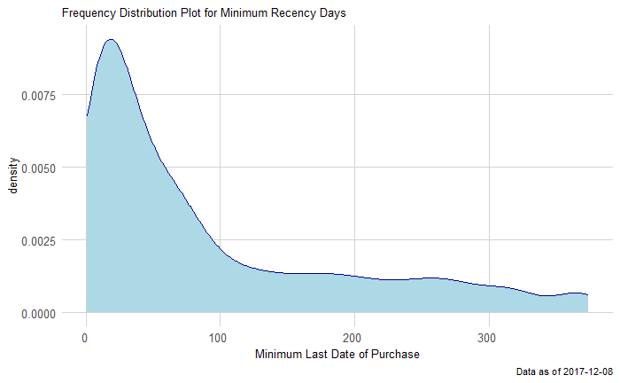

## 5.0 Apply RFM Customer Segment Technique

```r
analysis_date = as.Date("2017-12-08")
tmp_table <- rfm_table_customer(data = df_rfm,
                               customer_id = CustomerID,
                               n_transactions = transaction_count,
                               recency_days = Recency_days,
                               total_revenue = amount,
                               analysis_date = analysis_date)
rfm_table <- as.data.frame(tmp_table$rfm)
```

```r
segment_names <- c("VIPs", "Loyal Customers", "Potential Loyalist",
  "New Customers", "Promising", "Need Attention", "About To Sleep",
  "At Risk", "Can't Lose Them", "Lost")

recency_lower <- c(4, 2, 3, 4, 3, 2, 2, 1, 1, 1)
recency_upper <- c(5, 5, 5, 5, 4, 3, 3, 2, 1, 2)
frequency_lower <- c(4, 3, 1, 1, 1, 2, 1, 2, 4, 1)
frequency_upper <- c(5, 5, 3, 1, 1, 3, 2, 5, 5, 2)
monetary_lower <- c(4, 3, 1, 1, 1, 2, 1, 2, 4, 1)
monetary_upper <- c(5, 5, 3, 1, 1, 3, 2, 5, 5, 2)

rfm_tab2 <- rfm_segment(tmp_table, segment_names, recency_lower, recency_upper,
frequency_lower, frequency_upper, monetary_lower, monetary_upper)
```

## 6.0 Analyse Results & Characterize Segment

### 6.1 Analysis of Results

Now that we have defined and segmented our customers, we examined the distribution of customers across the segments using a Tree Map. This provided clarity on the VIP segment of this E-commence business.

```r
rfm_tab2 %>%
  group_by(segment) %>%
  summarise(
    Count = n()
  ) %>%
  ungroup() %>%
  ggplot(aes(area = Count, fill = Count, label = paste(segment, Count, sep = "\n"))) +
  geom_treemap() +
  geom_treemap_text(place = "centre", size = 10, colour = "white") +
  labs(subtitle = "Customer Segmentation based on RFM Scores",
           caption = stringr::str_glue("Data as of {as.Date('2017-12-08')}"))
```

[output not shown]

We further a profiled the customer segments to understand the distribution of their recency, purchase frequency and revenue contribution during the period.

```r
median_recency_plot
```

[output not shown]

```r
median_frequency_plot
```

[output not shown]

```r
median_monetary_plot
```

[output not shown]

### 6.2 Characterization of VIP Customer Segment

```r
rfm_tab2 %>% filter(segment == "VIPs") %>% summary()
```

[output not shown]

```r
vip_table <- rfm_tab2 %>%
  filter(segment == "VIPs") %>%
  inner_join(dfCopy, by = c("customer_id" = "CustomerID")) %>%
  mutate(recency_days = as.numeric(recency_days),
         Revenue = Quantity * UnitPrice,
         Country = stringr::str_replace_all(Country, rep_str),
         Country = fct_relevel(Country),
         Month = lubridate::month(InvoiceDate, label=TRUE, abbr=FALSE),
         Year = year(InvoiceDate)) %>%
  select(-c(3,4,5,6,7,8,9))
```

```r
summary(vip_table)
```

[output not shown]

- We further investigated which countries most of the high-value customers came from. Most of the high-value Customers were from **United Kingdom**, followed by **Ireland** and **German** in this order. Get more information from the visualization below.

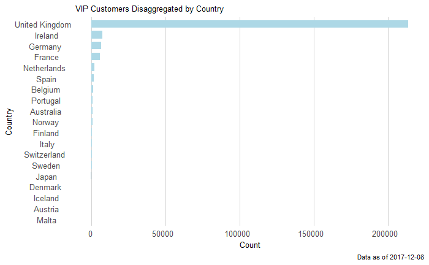

Lastly, since this is a gift shop sort of E-commence business, it would be nice to know what months or season of the year this high-value customer segment makes the most purchases.

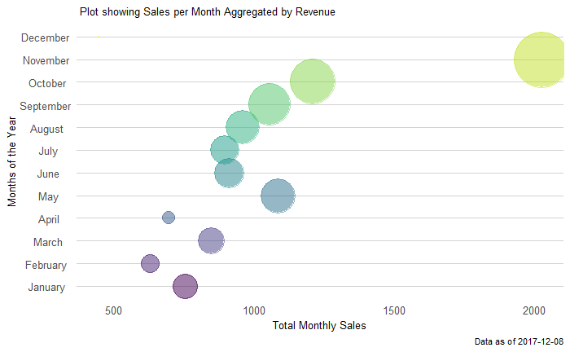

## 7.0 Conclusion

We can use promotional marketing strategies like discounts on commonly purchased items or discounts applied if a certain total invoice sum is surpassed during the last quarter of the year as a nudge to entice this segment of customers to keep around but also entice the loyal customer segment to join the high-value customers. During the other seasons of the year, we can use cues to reminder, to remind this segment of customers of existing exiting deals, products and offers.